# IB031 projekt(2)

**Projekt do IB031**

- [Zdroj](https://www.kaggle.com/altruistdelhite04/loan-prediction-problem-dataset)
- [Testing csv](https://www.kaggle.com/altruistdelhite04/loan-prediction-problem-dataset/download/evL45lGV3RssadtbrRzN%2Fversions%2FvfUNmIbaXE87YsRW0vw8%2Ffiles%2Ftest_Y3wMUE5_7gLdaTN.csv?datasetVersionNumber=1)
- [Training csv](https://www.kaggle.com/altruistdelhite04/loan-prediction-problem-dataset/download/evL45lGV3RssadtbrRzN%2Fversions%2FvfUNmIbaXE87YsRW0vw8%2Ffiles%2Ftrain_u6lujuX_CVtuZ9i.csv?datasetVersionNumber=1)

In this project we will implement several models to predict credibility of a loan applicant. We will use the Loan Prediction Problem Dataset from Kaggle. The structure of the project is as follows:

1. Exploratory Analysis
2. Preprocessing of the dataset
3. Decision tree classifier
4. KNN classifier
5. Support Vector Machine
6. Deep Neural Network
7. Evaluation
8. Conclusion

## 1. Exploratory Analysis

```python
import seaborn as sns
import pandas as pd
import numpy as np
import matplotlib as plt

sns.set()
```

Since pandas loads categorical data types as *'object'* dtype by default, we want to convert them back to category after loading the csv

```python
from sklearn.model_selection import train_test_split

#X_test = pd.read_csv("./test_Y3wMUE5_7gLdaTN.csv", index_col="Loan_ID")
dataset = pd.read_csv("./train_u6lujuX_CVtuZ9i.csv", index_col="Loan_ID")

for col in dataset.columns:
    if dataset[col].dtype == 'object':
        dataset[col] = dataset[col].astype('category')

X, y = dataset.drop(["Loan_Status"], axis=1), dataset["Loan_Status"][:]
y = y.map({"Y": True, "N": False})

X_train, X_test, y_train, y_test = train_test_split(X, y, test_size=.2)
```

```python
X.info()
```

```
<class 'pandas.core.frame.DataFrame'>
Index: 614 entries, LP001002 to LP002990
Data columns (total 11 columns):
Gender               601 non-null category
Married              611 non-null category
Dependents           599 non-null category
Education            614 non-null category
Self_Employed        582 non-null category
ApplicantIncome      614 non-null int64
CoapplicantIncome    614 non-null float64
LoanAmount           592 non-null float64
Loan_Amount_Term     600 non-null float64
Credit_History       564 non-null float64
Property_Area        614 non-null category
dtypes: category(6), float64(4), int64(1)
memory usage: 33.0+ KB
```

We have dropped the 'Loan_Status' column, which will provide labels during classification

```python
X.shape
```

```
(614, 11)
```

```python
y.shape
```

```
(614,)
```

We can look at the amount of distinct values of selected features.

```python
# value count of just some selected columns

print(X.Gender.value_counts()) # oh yeah boi
print(X.Married.value_counts())
print(X.Education.value_counts())
print(X.Property_Area.value_counts())
```

```
Male      489
Female    112
Name: Gender, dtype: int64
Yes    398
No     213
Name: Married, dtype: int64
Graduate        480
Not Graduate    134
Name: Education, dtype: int64
Semiurban    233
Urban        202
Rural        179
Name: Property_Area, dtype: int64
```

```python
X.head()
```

| Loan_ID | Gender | Married | Dependents | Education | Self_Employed | ApplicantIncome | CoapplicantIncome | LoanAmount | Loan_Amount_Term | Credit_History | Property_Area |
| --- | --- | --- | --- | --- | --- | --- | --- | --- | --- | --- | --- |
| LP001002 | Male | No | 0 | Graduate | No | 5849 | 0.0 | NaN | 360.0 | 1.0 | Urban |
| LP001003 | Male | Yes | 1 | Graduate | No | 4583 | 1508.0 | 128.0 | 360.0 | 1.0 | Rural |
| LP001005 | Male | Yes | 0 | Graduate | Yes | 3000 | 0.0 | 66.0 | 360.0 | 1.0 | Urban |
| LP001006 | Male | Yes | 0 | Not Graduate | No | 2583 | 2358.0 | 120.0 | 360.0 | 1.0 | Urban |
| LP001008 | Male | No | 0 | Graduate | No | 6000 | 0.0 | 141.0 | 360.0 | 1.0 | Urban |

```python
X.isnull().sum()
```

```
Gender               13
Married               3
Dependents           15
Education             0
Self_Employed        32
ApplicantIncome       0
CoapplicantIncome     0
LoanAmount           22
Loan_Amount_Term     14
Credit_History       50
Property_Area         0
dtype: int64
```

As we can see, there are a lot of null values which will need to be imputed. Since there is no column with more missing data than present, we do not need to drop any.

```python
X.describe()
```

|  | ApplicantIncome | CoapplicantIncome | LoanAmount | Loan_Amount_Term | Credit_History |
| --- | --- | --- | --- | --- | --- |
| count | 614.000000 | 614.000000 | 592.000000 | 600.00000 | 564.000000 |
| mean | 5403.459283 | 1621.245798 | 146.412162 | 342.00000 | 0.842199 |
| std | 6109.041673 | 2926.248369 | 85.587325 | 65.12041 | 0.364878 |
| min | 150.000000 | 0.000000 | 9.000000 | 12.00000 | 0.000000 |
| 25% | 2877.500000 | 0.000000 | 100.000000 | 360.00000 | 1.000000 |
| 50% | 3812.500000 | 1188.500000 | 128.000000 | 360.00000 | 1.000000 |
| 75% | 5795.000000 | 2297.250000 | 168.000000 | 360.00000 | 1.000000 |
| max | 81000.000000 | 41667.000000 | 700.000000 | 480.00000 | 1.000000 |

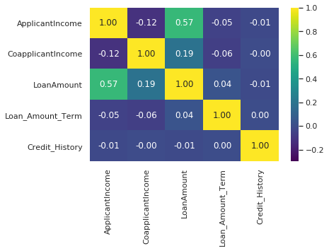

```python
sns.heatmap(X.corr(), annot=True, vmin=-0.3, cmap="viridis", fmt=".2f")
```

We also computed and plotted correlation matrix of features in the dataset. There is only one pair of features, loan amount and applicant income, which can be considered to be mildly positively correlated. Other features, have nearly no correlation among them. This results is quite suprising, as one would expect higher correlation of features.

```
array([[<matplotlib.axes._subplots.AxesSubplot object at 0x7f5dfc30c128>,
      dtype=object)
```

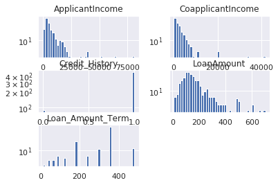

```python
X.hist(bins=40, log=True)
```

Most of the features are scattered along the x-axis. The only exception is Loan Amount, which roughly follows the normal distribution.

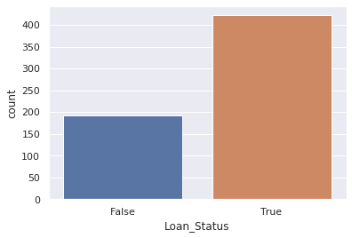

```python
sns.countplot(y)
```

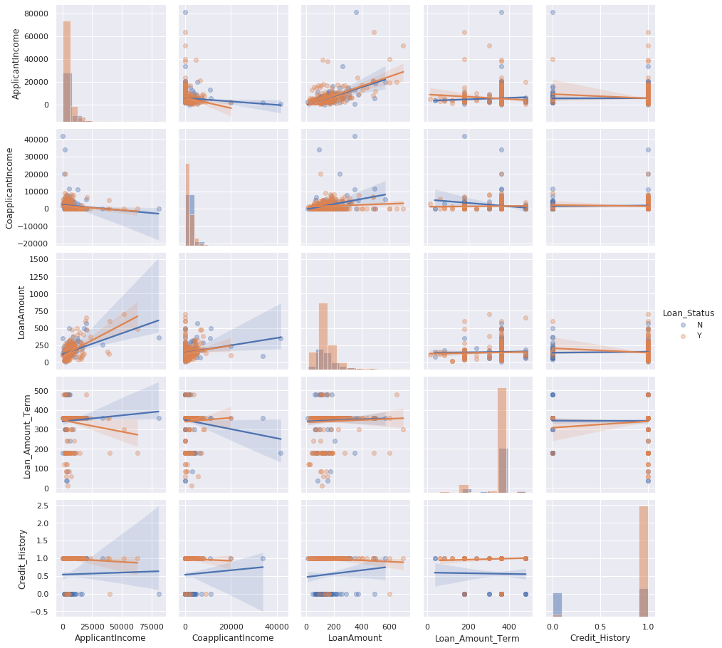

```python
sns.pairplot(dataset, hue="Loan_Status", diag_kind="hist", kind="reg", diag_kws={"histtype": "barstacked", "alpha": 0.5}, plot_kws={"scatter_kws": {"alpha": 0.35}})
```

Credit history seems to have the highest impact on deciding whether the loan should be approved or not. Clients with low credit score seem more likely to be denied.

There are some cases where ApplicantIncome and CoapplicantIncome are very low, their loan request gets approved, whereas in a few cases the CoapplicantIncome is very high and ApplicantIncome is very low, the request gets denied.

## 2. Data preprocessing

```python
y.isna().sum()
```

```
0
```

Good, there are no N/A labels. We do not need to drop any whole rows.

First, let's encode categorical values with OneHotEncoding

```python
from sklearn.preprocessing import OrdinalEncoder, OneHotEncoder, StandardScaler
from sklearn.pipeline import make_pipeline
from sklearn.compose import make_column_transformer
from sklearn.impute import SimpleImputer
from sklearn_pandas import DataFrameMapper

class NpToDf:
    columns = []

    def __init__(self, columns=None):
        self.columns = columns

    def fit(self, X, *args, **kwargs):
        return X

    def fit_transform(self, X, *args, **kwargs):
        return self.transform(X)

    def transform(self, X, *args, **kwargs):
        return pd.DataFrame(data=X, columns=self.columns)

pipe_X = make_pipeline(
    SimpleImputer(missing_values=np.nan, strategy="most_frequent"),
    NpToDf(X_train.columns),
    make_column_transformer(
        (OneHotEncoder(), ['Gender', 'Married', 'Education', 'Self_Employed', 'Property_Area', 'Dependents']),
        remainder=StandardScaler()),
    NpToDf(),
)

pipe_y = make_pipeline(
    OrdinalEncoder()
)
```

```python
pipe_X.fit_transform(X_train)
train_X = pipe_X.transform(X_train)
test_X = pipe_X.transform(X_test)

train_y = pipe_y.fit_transform(y_train.to_numpy().reshape(-1, 1)).reshape(-1)
test_y = pipe_y.fit_transform(y_test.to_numpy().reshape(-1, 1)).reshape(-1)
```

Some helper functions for training and evaluation of our models.

```python
from sklearn.metrics import mean_squared_error, f1_score
from sklearn.model_selection import cross_val_score
import matplotlib.pyplot as plt

def evaluate(clf, X_test, y_test):
    y_pred = clf.predict(X_test)
    scores = cross_val_score(clf, X_test, y_test, cv=10)

    print(f"RMSE: {mean_squared_error(y_test, y_pred, squared = False):.4f}")
    print(f"Accuracy: {scores.mean():.3f} ± {scores.std() * 2:.3f}")
    print("F1 Score: %.2f" % f1_score(y_test, y_pred, average='weighted'))
```

```python
from sklearn.metrics import plot_roc_curve

def roc(clf, test_X, test_y):
    plot_roc_curve(clf, test_X, test_y)
    plt.plot([0, 1], [0, 1], linestyle='--', lw=2, color='r', label='Chance', alpha=.8)
    plt.legend()
```

```python
from sklearn.metrics import plot_precision_recall_curve
from sklearn.metrics import precision_recall_curve

def prc(clf, test_X, test_y):
    plot_precision_recall_curve(clf, test_X, test_y)
```

```python
from sklearn.metrics import plot_confusion_matrix
from sklearn.metrics import confusion_matrix
from sklearn.model_selection import GridSearchCV

def confusion(clf, X_test, y_test):
    plot_confusion_matrix(clf, X_test, y_test, cmap=plt.cm.Blues)
```

```python
def get_gscv(clf, param_grid):
    gs = GridSearchCV(clf, param_grid)
    gs.fit(train_X, train_y)
    score = gs.score(test_X, test_y)
    print(f"Best parameters: {gs.best_params_}, with F1 score of {score:.2f}")
    return (score, gs.best_params_)
```

## 3. Decision tree classifier

```python
from sklearn.tree import DecisionTreeClassifier

dtree_clf = DecisionTreeClassifier()
dtree_values = {"criterion": ["gini", "entropy"],
                "max_depth": [1, 2, 5, 10, 16, None],
                "max_leaf_nodes": [6, 8, 10, 12, 20, None],
                "max_features": ["auto", "sqrt", "log2", 2, 4, 8]}

score, params = get_gscv(dtree_clf, dtree_values)
```

```
Best parameters: {'criterion': 'entropy', 'max_depth': None, 'max_features': 8, 'max_leaf_nodes': 12}, with F1 score of 0.75
```

```
RMSE: 0.4771
Accuracy: 0.657 ± 0.248
F1 Score: 0.75
```

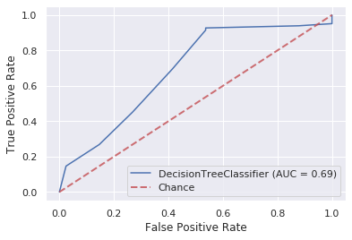

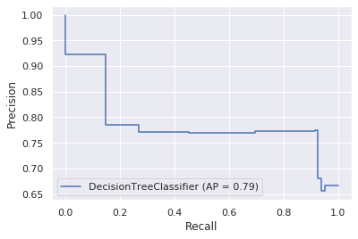

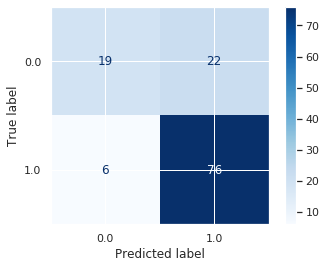

```python
tree_clf = DecisionTreeClassifier(**params)
tree_clf.fit(train_X, train_y)
evaluate(tree_clf, test_X, test_y)
roc(tree_clf, test_X, test_y)
prc(tree_clf, test_X, test_y)
confusion(tree_clf, test_X, test_y)
plt.show()
```

## 4. KNN classifier

```python
from sklearn.neighbors import KNeighborsClassifier

knn_clf = KNeighborsClassifier()
knn_values = {"n_neighbors": list(range(2, 16, 2)),
              "algorithm": ["auto", "ball_tree", "kd_tree", "brute"],
              "leaf_size": [10, 20, 30, 40, 50],
              "p": [1, 2],
              "weights": ["uniform", "distance"]}

score, params = get_gscv(knn_clf, knn_values)
```

```
Best parameters: {'algorithm': 'auto', 'leaf_size': 10, 'n_neighbors': 14, 'p': 2, 'weights': 'uniform'}, with F1 score of 0.80
```

[output not shown]

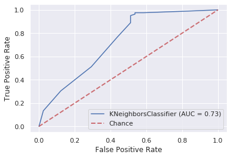

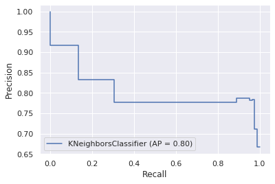

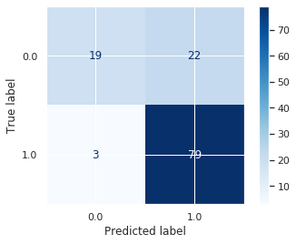

```python
knn_clf = KNeighborsClassifier(**params)
knn_clf.fit(train_X, train_y)
evaluate(knn_clf, test_X, test_y)
roc(knn_clf, test_X, test_y)
prc(knn_clf, test_X, test_y)
confusion(knn_clf, test_X, test_y)
plt.show()
```

## 5. Support Vector Machine

```python
from sklearn.svm import SVC

svc_clf = SVC()
svc_values = {"C": [.8, 1.0, 1.2, 1.5, 2.0],
              "kernel": ["linear","poly","rbf","sigmoid"],
              "degree": [2, 3, 4, 5],
              "gamma": ["scale", "auto"],
              "coef0": [.0, .5, 1.0, 1.5]}

score, params = get_gscv(svc_clf, svc_values)
```

```
Best parameters: {'C': 1.0, 'coef0': 1.5, 'degree': 2, 'gamma': 'scale', 'kernel': 'sigmoid'}, with F1 score of 0.78
```

[output not shown]

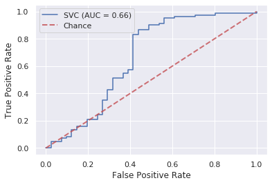

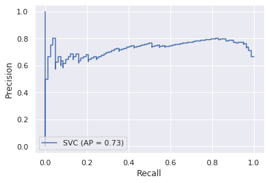

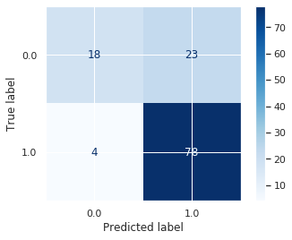

```python
svm_clf = SVC(**params)
svm_clf.fit(train_X, train_y)

evaluate(svm_clf, test_X, test_y)
roc(svm_clf, test_X, test_y)
prc(svm_clf, test_X, test_y)
confusion(svm_clf, test_X, test_y)
plt.show()
```

## 6. Deep Neural Network

```python
from tensorflow import keras
import tensorflow as tf
from keras.models import Sequential

from keras.layers import Dense
from sklearn.metrics import classification_report, confusion_matrix
from tensorflow.keras import layers


print(y_train.shape)
```

```
(491,)
```

```python
nn = Sequential()

nn.add(Dense(units=128, activation='relu', input_shape=(train_X.shape[1],)))
nn.add(Dense(units=64, activation='relu'))
nn.add(Dense(units=32, activation='relu'))
nn.add(Dense(units=2, activation='softmax'))

nn.compile(loss='categorical_crossentropy', optimizer='adam', metrics=['accuracy'])

nn.summary()
```

```
Model: "sequential_1"
_________________________________________________________________
Layer (type)                 Output Shape              Param #
=================================================================
dense_1 (Dense)              (None, 128)               2688
_________________________________________________________________
dense_2 (Dense)              (None, 64)                8256
_________________________________________________________________
dense_3 (Dense)              (None, 32)                2080
_________________________________________________________________
dense_4 (Dense)              (None, 2)                 66
=================================================================
Total params: 13,090
Trainable params: 13,090
Non-trainable params: 0
_________________________________________________________________
```

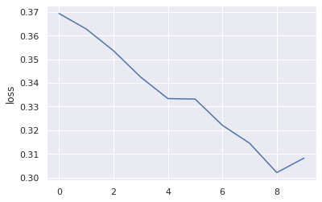

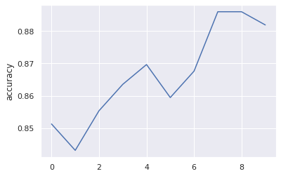

[output not shown]

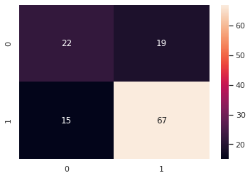

```python
ohe = OneHotEncoder()

nn_train_y = ohe.fit_transform(y_train.to_numpy().reshape(-1, 1))
nn_test_y = ohe.transform(y_test.to_numpy().reshape(-1, 1))

data = nn.fit(train_X, nn_train_y, batch_size=32, epochs=10, verbose=False)

predicted_y = nn.predict(test_X)

history_df = pd.DataFrame(data=data.history, columns=data.history.keys())

sns.lineplot(legend='full', y='loss', x=range(len(data.history['loss'])), data=history_df)
plt.show()
sns.lineplot(legend='full', y='accuracy', x=range(len(data.history['accuracy'])), data=history_df)
plt.show()

predicted_y_labels = np.argmax(predicted_y, axis=1)

true_y_labels = np.argmax(nn_test_y, axis=1)

# evaluate(nn, test_X, nn_test_y)

sns.heatmap(confusion_matrix(true_y_labels, predicted_y_labels), annot=True)

print('\nClassification Report')
target_names = ["Y", "N"]
print(classification_report(true_y_labels, predicted_y_labels, target_names=target_names))
```